# PAA Session 413: Race, Ethnicity, and Population Health Comparison of rates of firearm and non-firearm homicide and suicide in black and white non-Hispanic men by US state

Corinne Riddell, PhD, Postdoctoral Fellow, McGill University

April 28, 2018

# Racial disparities in violent deaths are well-established in the US

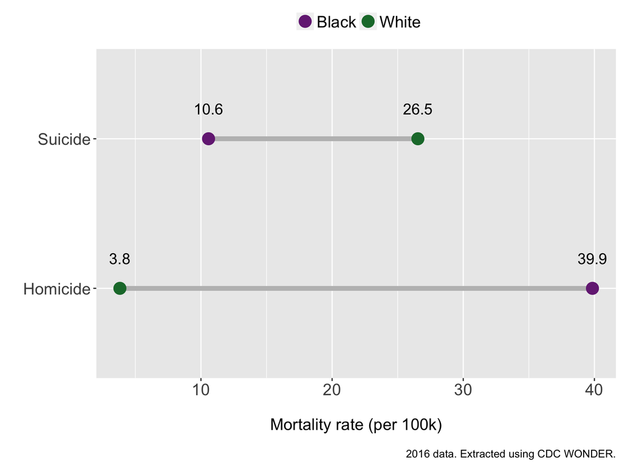

# What might variation across states imply?

- Differences in race-specific levels of exposures to:
  - Neighborhood residential conditions
  - Medical care
  - Policy environments, such as gun ownership

# Gun ownership and gun deaths

[figure not shown]

https://www.motherjones.com/politics/2013/01/pro-gun-myths-fact-check/

# Gun ownership, homicide, and suicide

- Case-control studies estimate positive associations between:
  - Gun in the home and homicide in the home (Kellermann et al., NEJM. 1993)
  - Gun in the home and household risk of suicide (Kellermann et al., NEJM. 1992)

# Gun ownership, homicide, suicide, and race

- Two component causes of homicide and suicide:
  - Opportunity
    - Access to guns increases opportunity for violence
  - Motivation
    - Participation in drug markets increases risk of homicide
    - Social support, cultural cohesion decrease risk of suicide

# Study Objectives

1. Estimate the absolute inequality between non-Hispanic black and white men in firearm- and non-firearm homicide and suicide across US states
2. Examine the relationships between state gun ownership prevalence, firearm homicide, and firearm suicide, separately for black and white men.

# Data

- Extracted from the CDC WONDER Online database of mortality statistics
- 50 states + DC
- 2008–2016
- Males of all ages (**Men**, without loss of generality)
- Non-Hispanic **black** and **white**
- For each state: Age adjusted **homicide** and **suicide** rates and their racial inequalities, by **firearms use**
- From the 2004 Behavioral Risk Factor Surveillance System (**BRFSS**), calculated state household gun ownership (%):
  - Low: 10.2%-19.9%
  - Medium-low: 20.0%-34.9%
  - Medium-high: 35.0%-44.9%
  - High: 45.0%-65.5%

# Results

- This analysis included 84,113 homicides and 251,772 suicides between 2008 and 2016.
- Death rates were withheld for any state with fewer than 20 deaths in a strata between 2008 and 2016.

# Rate differences in firearm homicide

# Rate differences in firearm homicide

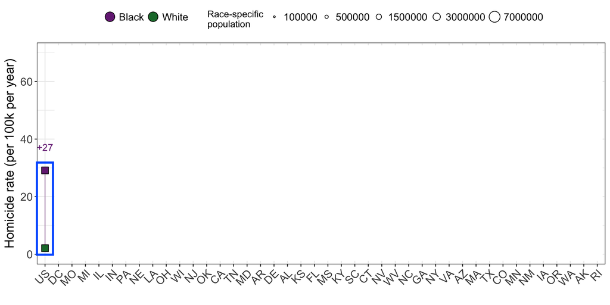

# Rate differences in firearm homicide

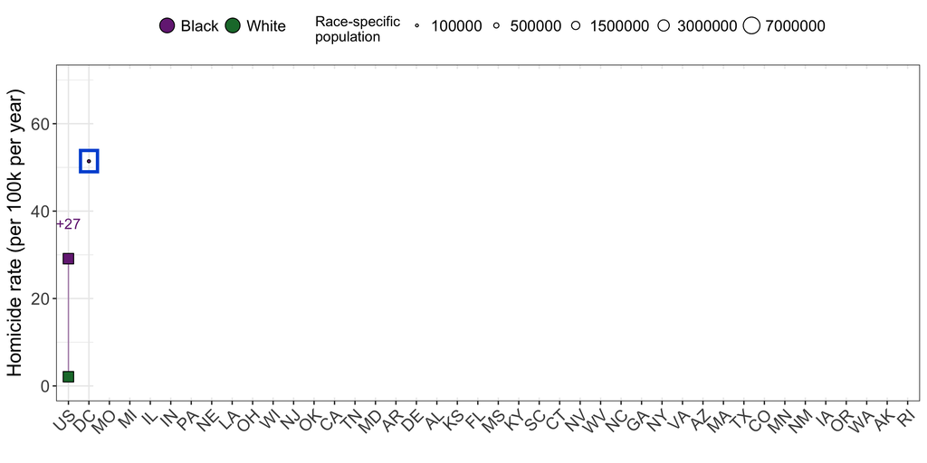

# Rate differences in firearm homicide

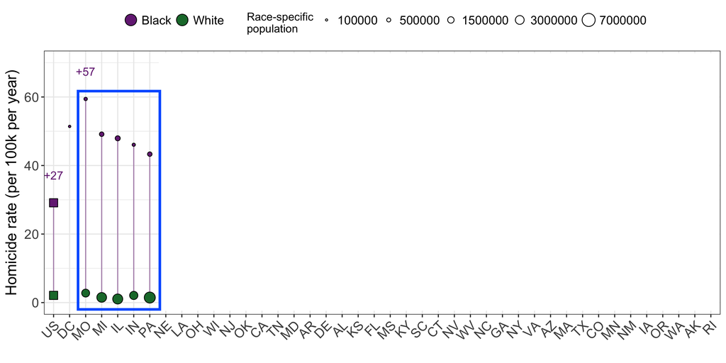

# Rate differences in firearm homicide

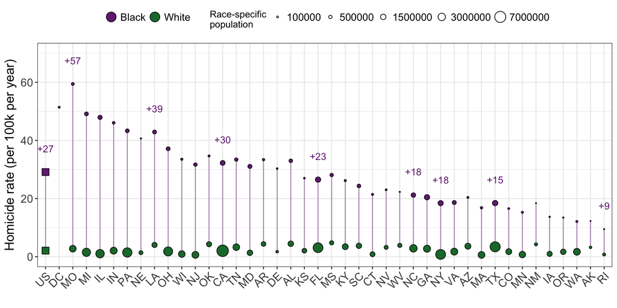

# Rate differences in homicide and suicide

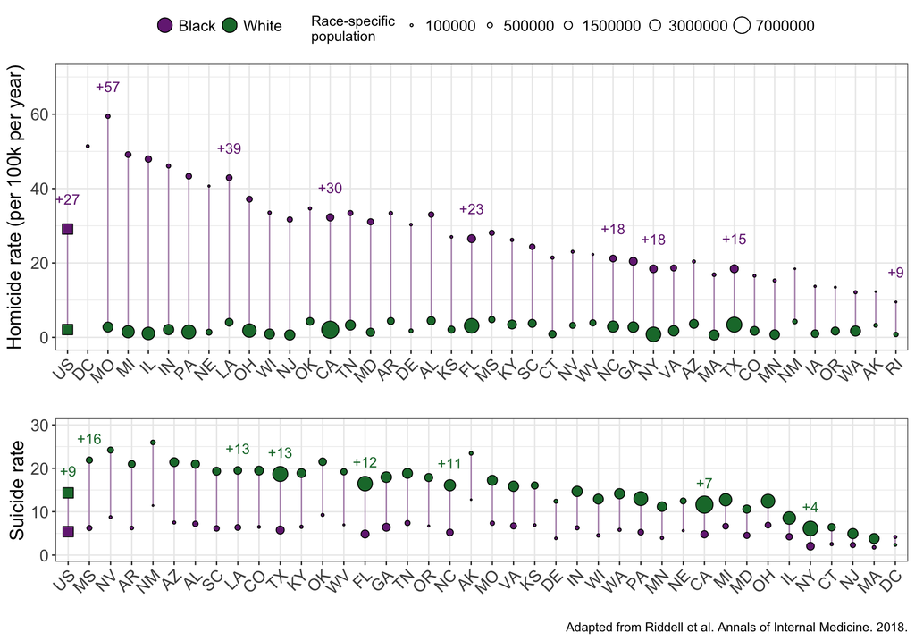

# Homicide, suicide, and state gun ownership (%) for white men

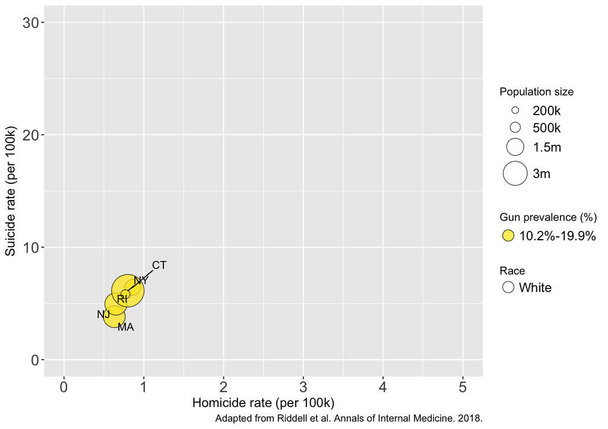

# Homicide, suicide, and state gun ownership (%) for white men

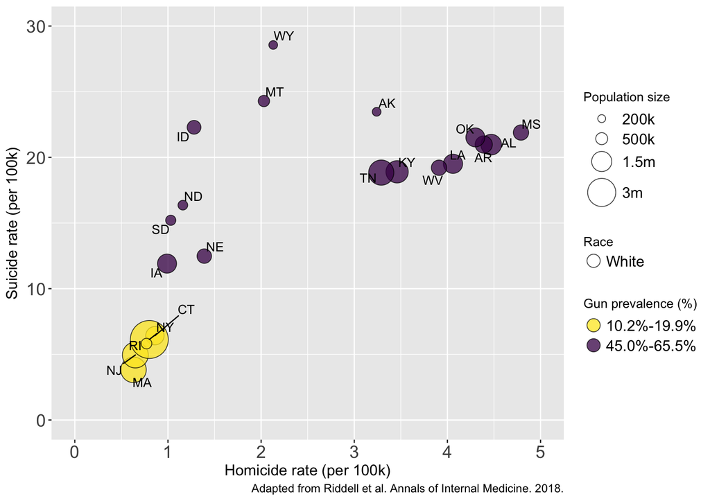

# Homicide, suicide, and state gun ownership (%) for white men

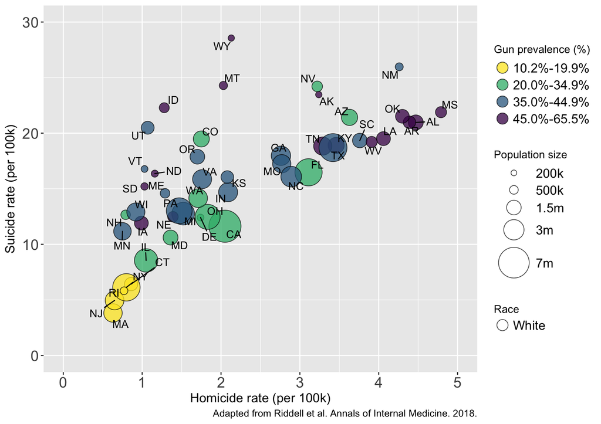

# Homicide, suicide, and state gun ownership (%) for white men

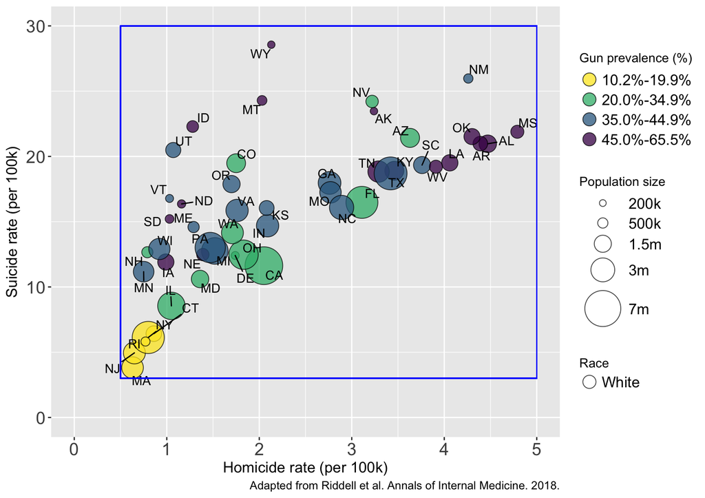

# Homicide, suicide, and state gun ownership (%) for white and black men

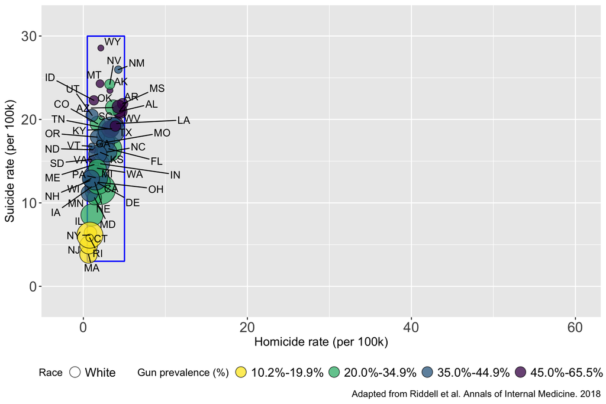

# Homicide, suicide, and state gun ownership (%) for white and black men

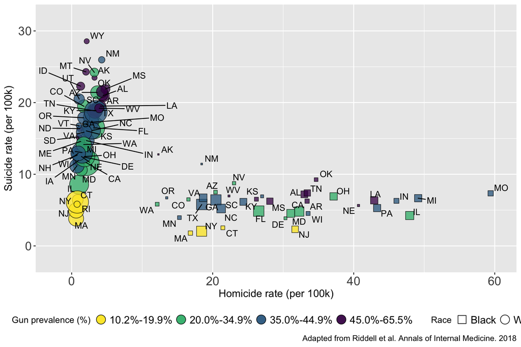

# Discussion

- The mechanisms that have led to varying racial inequalities across states is unclear.
- Black men are at higher risk of homicide because of:
  - Structural disadvantage (poverty, joblessness, family disruption)
  - Racial residential segregation
  - Participation in drug markets
- These factors may occur more frequently within states with larger disparities in firearm homicide

# Discussion

- Studies of gun policy have estimated reductions in homicide and suicide because of specific policies
- Whether these policies are linked to racial disparities is unclear, but worthy of investigation

# Discussion

- Alcohol is a risk factor for suicide and may play a role in the increased rate of suicides among white men
- Variation in alcohol use across states may be implicated in the magnitude and direction in the racial inequality in suicide

# Questions?

https://github.com/corinne-riddell/InjuryDisparity

corinne.riddell@mail.mcgill.ca

@datavisitor

# Hypothetical pathways: suicide

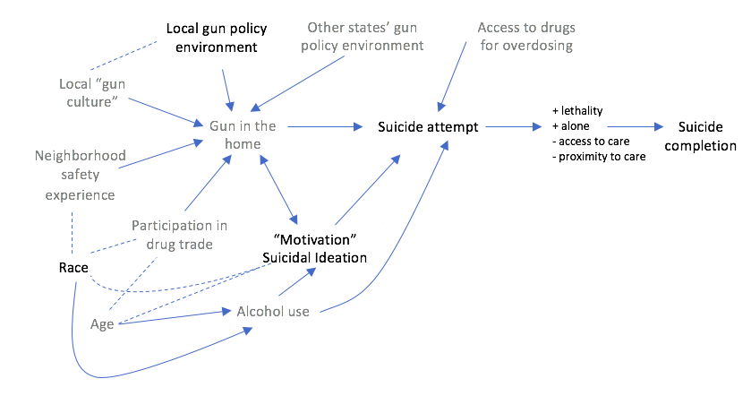

# Hypothetical pathways: homicide

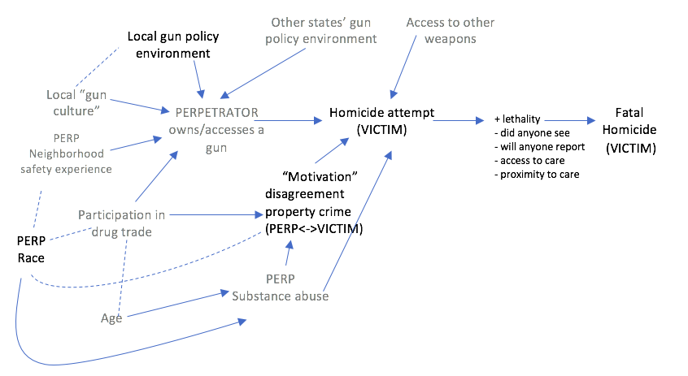

[figure not shown]

# Why does it matter?

- Identification of subpopulations with an excess burden of injury
- Interventions directed to reduce inequalities and overall levels of violent deaths